# XGBoost permutation sweep — model, split & knob params

2026-06-19

## Summary

The reference model is the **selected version**: an XGBoost classifier with an **adaptive train/test split** (auto-tuned label-weights + seed search) and a **12-model CV grid** for hyperparameters. This report runs a permutation sweep over **three parameter families** and lets each family “vote” for its best setting, to see whether any combination beats the selected version.

- **Model param** — 10 hyperparameter variants (M1–M10), on a fixed split.
- **Split (train/test) param** — 10 directed variants (S1–S10) + a 27-cell grid (V1–V27: test-frac × critical-weight × min-count floor).
- **Knob param** — 4 data/weighting ablations (A1–A4).

> **Reading the metrics.** Overall **Accuracy** is dominated by the Tumor majority. The real tuning target is **critical-class recall** (mean sensitivity over the rare types: MDSC, BnT, Igg, mregDC, PMN_MDSC, Neutrophil) and **Kappa**. **Caveat:** the selected version and each split permutation use *different* held-out sets, so metrics are **indicative, not strictly comparable**; the selected version’s tiny rare-class test counts (below) inflate its rare-class recall. Only the M1–M10 model-param variants share one fixed split and are mutually comparable.

### How the sweep works — voting across three families

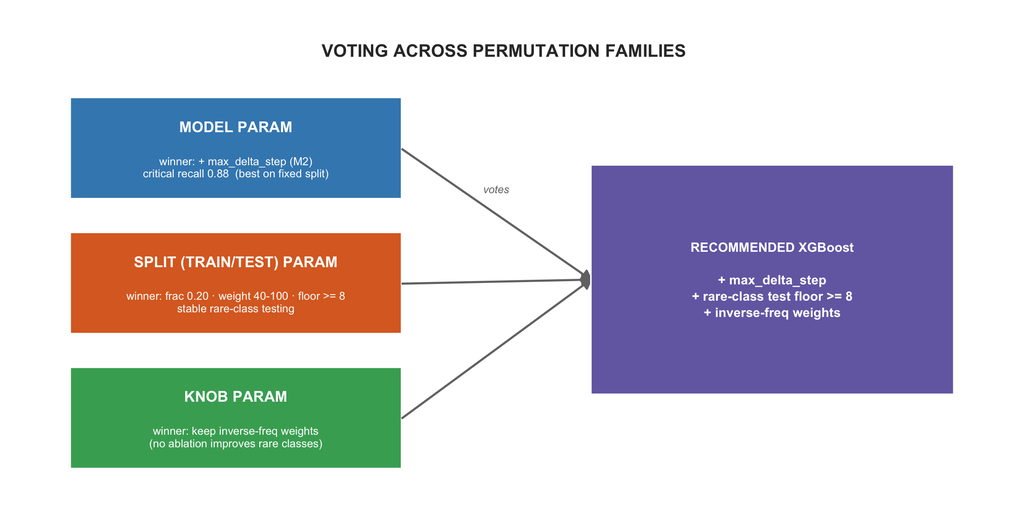

### Critical-class recall scorecard

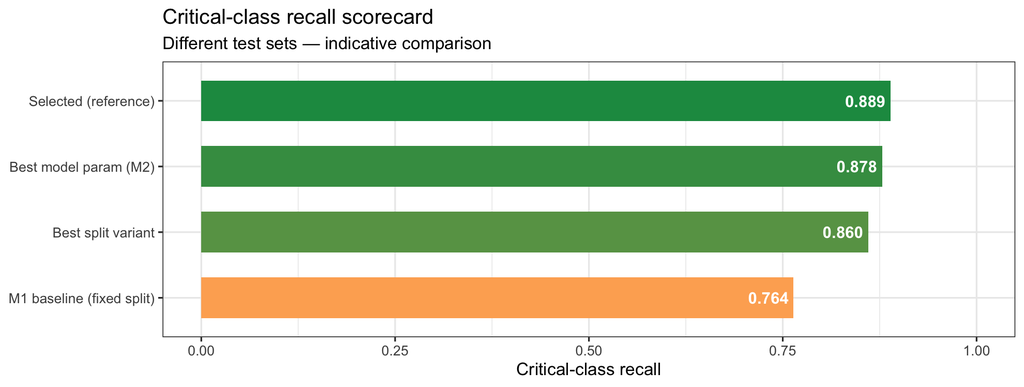

## Selected reference version

Selected version configuration (reproduced on the cached cells)

| component | value |
| --- | --- |
| Split protocol | auto-tuned label_weights + 200-seed search |
| default / rare test frac | 0.2 / 0.2 |
| rare threshold | < 150 cells = rare |
| best seed | 1 |
| test images / cells | 7 / 6,355 |
| min rare-class test cells | 2 |
| Model param grid | depth{3,4,5} x eta{.05,.1} x mcw{1,5}, sub/col=0.8 (no gamma/lambda/alpha/mds) |
| selected (max_depth / eta / min_child_weight / nrounds) | 5 / 0.05 / 5 / 163 |

Selected version critical-class recall — note the tiny test counts behind the 1.000s

| class | sensitivity |
| --- | --- |
| MDSC | 0.667 |
| BnT | 0.667 |
| Igg | 1.000 |
| mregDC | 1.000 |
| PMN_MDSC | 1.000 |
| Neutrophil | 1.000 |

The selected version reaches **critical recall 0.889**, **Kappa 0.974**, balanced accuracy 0.972. But its adaptive split leaves as few as **2 cells** for some rare classes in the test set, so several class sensitivities are 1.000 over 2–3 cells — high but high-variance. Its chosen config is a flexible **depth-5** tree with no extra regularization; the permutation study below tests whether added regularization and a guaranteed rare-class test floor do better.

## Model param permutation (M1–M10)

Same split (`split_main`), varying XGBoost hyperparameters. Sorted by critical-class recall.

Model-param variants (test set), sorted by critical-class recall

| model_id | config | max_depth | eta | gamma | lambda | max_delta_step | nrounds | Accuracy | Kappa | BalAcc | Crit recall |
| --- | --- | --- | --- | --- | --- | --- | --- | --- | --- | --- | --- |
| M2 | +max_delta_step | 3 | 0.10 | 0 | 1 | 1 | 121 | 0.947 | 0.837 | 0.926 | 0.878 |
| M8 | depth probe | 5 | 0.05 | 1 | 5 | 1 | 343 | 0.948 | 0.838 | 0.918 | 0.821 |
| M9 | conservative | 3 | 0.05 | 1 | 1 | 1 | 223 | 0.955 | 0.858 | 0.928 | 0.820 |
| M10 | balanced reg | 4 | 0.05 | 1 | 5 | 1 | 341 | 0.946 | 0.834 | 0.927 | 0.820 |
| M4 | +L2 | 4 | 0.05 | 1 | 5 | 1 | 175 | 0.949 | 0.843 | 0.914 | 0.800 |
| M3 | slower + gamma | 3 | 0.05 | 1 | 1 | 1 | 223 | 0.946 | 0.833 | 0.915 | 0.788 |
| M1 | baseline (current best) | 3 | 0.10 | 0 | 1 | 0 | 70 | 0.945 | 0.830 | 0.905 | 0.764 |
| M6 | strong reg | 3 | 0.03 | 1 | 5 | 2 | 208 | 0.949 | 0.843 | 0.909 | 0.764 |
| M7 | flexible | 4 | 0.10 | 0 | 1 | 0 | 58 | 0.959 | 0.867 | 0.898 | 0.750 |
| M5 | more sampling | 4 | 0.05 | 0 | 1 | 1 | 211 | 0.983 | 0.942 | 0.900 | 0.640 |

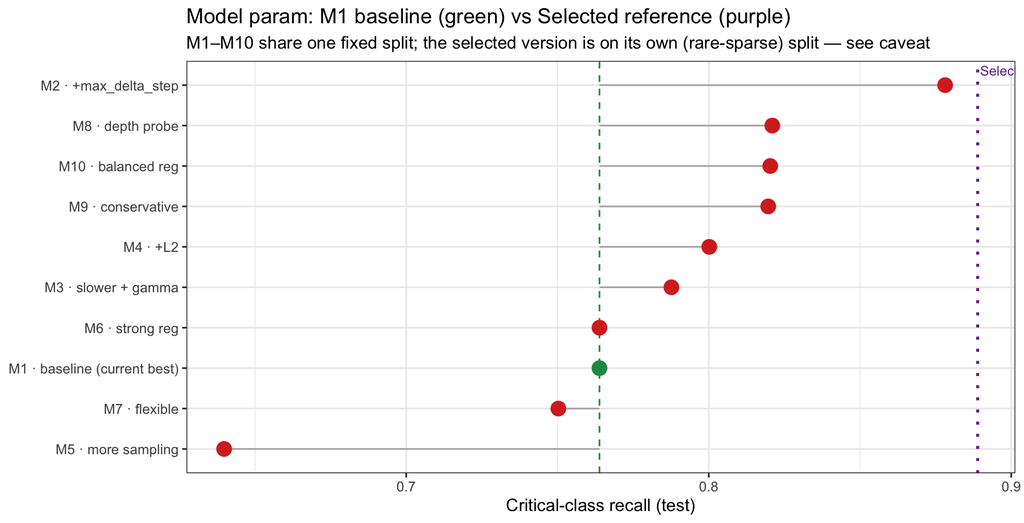

## Split (train/test) param permutation

The split changes which images/cells are held out, so accuracy is not comparable; we judge splits by **critical-class recall** and **rare-class coverage** (`min_test_count_observed` — the smallest number of test cells any critical class gets).

### Directed sweep (S1–S10)

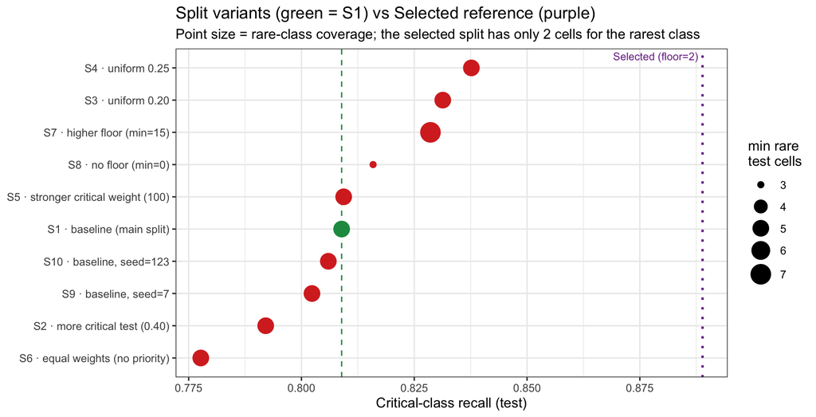

### Full grid (V1–V27): frac × critical-weight × floor

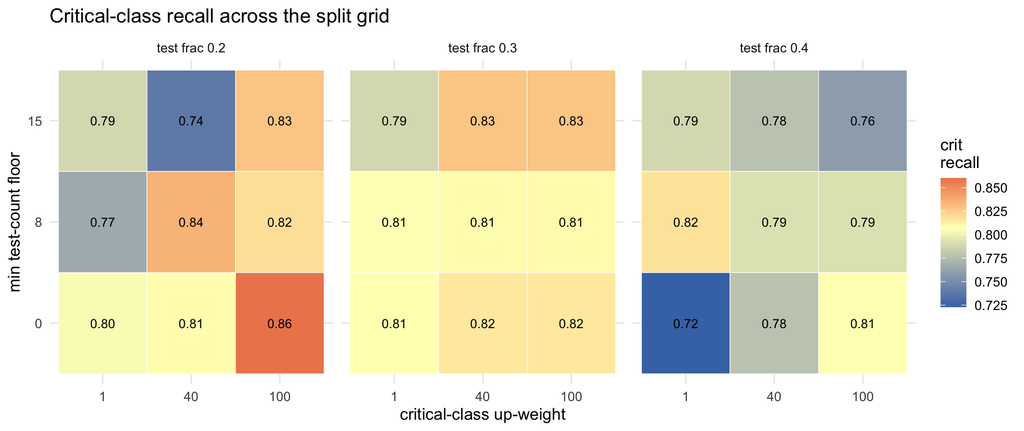

## Knob param permutation (A1–A4)

These change the **data or class weights**, not the tree hyperparameters (all use the M1 config).

Knob (ablation) variants vs baseline M1

| model_id | knob | Accuracy | Kappa | BalAcc | Crit recall |
| --- | --- | --- | --- | --- | --- |
| A1 | ablation_capped_weights | 0.981 | 0.934 | 0.892 | 0.710 |
| A2 | ablation_drop_undefined | 0.980 | 0.927 | 0.887 | 0.667 |
| A3 | ablation_area_qc | 0.986 | 0.952 | 0.889 | 0.676 |
| A4 | ablation_outlier_remove | 0.984 | 0.943 | 0.894 | 0.671 |

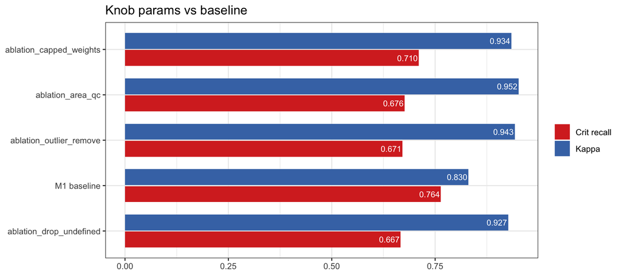

**Takeaway:** every knob (capping weights, dropping `undefined`, area QC, outlier removal) *raises* Kappa/accuracy but *lowers* critical recall — they trade rare-class sensitivity for cleaner majority-class fit. None win the vote on the metric that matters here.

## Conclusion — what wins the vote

*Net: the selected version is strong (Kappa 0.974, balanced accuracy 0.972), but its rare-class evaluation is under-powered. The two upgrades that win the vote are **`max_delta_step` in the model param** and a **rare-class test-count floor in the split** — neither is in the current pipeline.*